# WEEK 1

Course motivation and overview

Felipe Campelo

## Unit team

Unit Director Dr. Felipe Campelo, Assoc. Prof. in Data Science f.campelo@bristol.ac.uk

Dr. Zining WangLecturer in Financial Technology

zining.wang@bristol.ac.uk

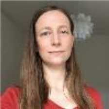

Dr. Sarah SachsLecturer in Statistical Science

sarah.sachs@bristol.ac.uk

Dr. Amilcar Soares Jr. Snr. Lecturer in Data Science

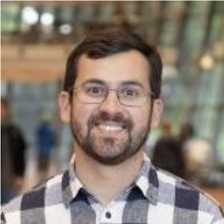

[figure not shown]

+ the SCEM TSR team (lab support)

[figure not shown]

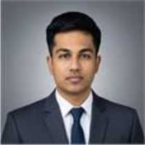

[figure not shown]

Sarvenaz

Edward

James

Tanishk

Xiaoxiao

Xiaofei

## Statistical Computing and Empirical Methods

What’s this course about?

In this course you'll gain a broad understanding of some of the fundamental statistical principles and methods necessary for a successful career in data-intensive fields.

How is this useful?

Let’s do a quick experiment…

[figure not shown]

[figure not shown]

## Data gathering

Please take 15 seconds to answer 2 simple questions using this link.(please do it – it’s more fun when we have live data)

[https://forms.cloud.microsoft/e](https://forms.cloud.microsoft/e/J5qJw7d4CG)/J5qJw7d4CG

## A/B testing

A/B testing (also know as split testing) is a common technique used to run online experiments, usually to assess user responses to changes in a system (e.g., changes in click-through rates, average sales value, etc.).

Methodologically speaking, there’s nothing new about A/B testing – they are just one example of coupling classic statistical methods with modern data-gathering capabilities, to reach statistically sound conclusions.

We have just run our first A/B test (sort of). Let’s walk through it.

[figure not shown]

## Step 1: Defining a question of interest

The form you just completed was designed to test what is known as the anchoring bias1 – the tendency of people to rely on some initial piece of information (even if irrelevant) when trying to estimate a quantity.

In this case, the same question about the oven price was presented with two different images, randomly presented (with the birth date used to randomise the allocation). Is there an effect of the perception of a “promotion”? (which could affect how much a person would be willing to pay for the product)

How can we measure the differences and test if the differences are due to a real effect of the options given, or just random noise?

[figure not shown]

[figure not shown]

## Step 2: Formalising the question

Each person will have their own opinion on the actual value of the item. Predicting an individual’s reaction is almost impossible with the information we have. However, we are instead interested in the general effect on the population, not on a specific person.

(We will learn about point estimation in week 2)

## Step 2: Formalising the question

In statistical terms, this is commonly formalised as a pair of statistical hypotheses:

(We will learn about comparative experiments in weeks 7-8)

## Step 2: Formalising the question

In statistical terms, this is commonly formalised as a pair of statistical hypotheses:

(We will learn about comparative experiments in weeks 7-8)

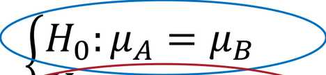

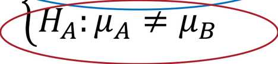

Null hypothesis(no effect)

Alternative hypothesis(some effect)

## 3. Designing the experiment

Given a question of interest, formalised as statistical hypotheses, how to go about testing those hypotheses?

This includes considerations about:

- Which statistical test to use?
- What is the desired level of confidence?
- What is the smallest relevant difference we want to be able to detect?
- What is the desired sensitivity (a.k.a. statistical power) of the experiment?
- What are the required (or the available) sample sizes?

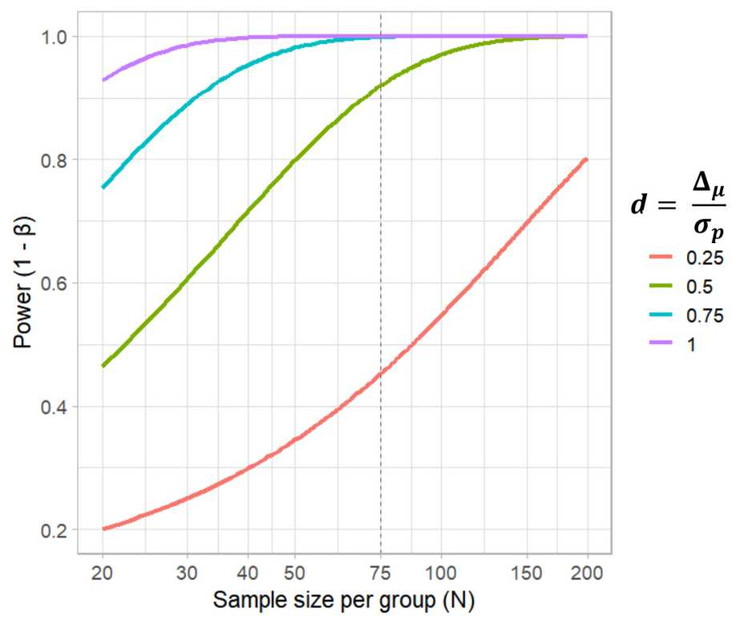

(We will learn about experimental design in weeks 6-9)

[figure not shown]

## 4. Exploratory Data Analysis

An important part of any data analysis task is to get a sense of what the data “looks like” – to check for data inconsistencies, missing values, the general shape of the data distributions, etc.

This process is known as Exploratory Data Analysis (EDA). It commonly combines visuals and summary statistics.

[figure not shown]

(We will learn about EDA in weeks 3-5)

## 5. Testing hypotheses

Hypothesis testing is used to extract conclusionsabout (unknown) populational parameters based on (known) sample statistics.

Broadly speaking, statistical hypothesis testing works by comparing the value of some test statistic (calculated from the data) with what values would be expected under the null hypothesis (“no effect”).

If the observed scenario is inconsistent with the expected “no effects” behaviour, it is said that the null hypothesis is rejected.

(We will learn about hypothesis testing in weeks 5-9)

## 6. Reporting

Once we finish our analyses, it is important to adequately report the results, including the estimated differences (and the precision associated with those estimates, e.g., in the form of confidence intervals), the results of the hypothesis testing, etc.

In practice it is important to report the statistics, but also to step back and describe what the results mean in the context of the problem – for instance, what does it mean to have a significant difference in perceived value, in the context of that online store?

(We will learn about statistical intervals in week 3)

## Tying these concepts to the course structure

In this course, you will learn about statistical computing and empirical methods through two main learning modes:

- learn-by-watching: weekly live lectures + asynchronous video content. In these sessions, concepts are introduced and discussed.

Important: keeping up with the video contents is just as important as attending the lectures - some items are only covered in the lectures, others only in the videos.

- learn-by-doing: weekly lab sessions. In these sessions you’ll consolidate your learning and, as the course advances, get some hands-on experience with more complex computational statistical methods.

Important: don’t neglect the lab activities. Besides getting some practical knowledge in R, these sessions are a great opportunity to ask questions about the unit and get some feedback to check your understanding, and they’ll also prepare you for the final coursework.

## A typical week:

[figure not shown]

## A typical week: Temple Quarter cohorts

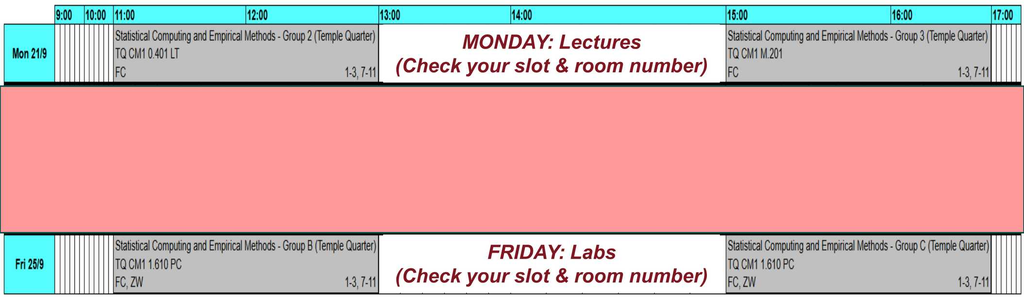

[figure not shown]

MONDAY: Lectures(Check your slot & room number)

FRIDAY: Labs(Check your slot & room number)

## A typical week: Clifton cohort

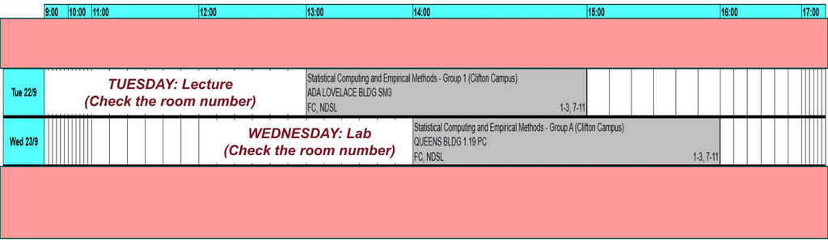

[figure not shown]

TUESDAY: Lecture(Check the room number)

WEDNESDAY: Lab(Check the room number)

[figure not shown]

## A typical week:

Each week there may also be one or more supplementary (online-only) materials.

They can be viewed at a time of your choosing, but it is recommended to do so between the in-person lectures and the labs. I suggest adding a fixed time slot into your calendar (between the lecture and the lab sessions) and making it a habit.

If you don’t come prepared, you are likely to benefit less from the sessions.

## Assessment

Formative assignments (does not count towards your final score)

Type: Weekly lab assignments.

Feedback: Live discussions during the lab sessions. Cohort-wide discussion of previous week assignment at the start of each lab.

Summative assessment (counts towards your final score)

Type: Final coursework (100%). Composed of a series of tasks (computational and/or theoretical) to assess the knowledge and skills acquired in the unit. More details released in October. Deadline: early December.

Feedback: Provided after marking. Summary of marks + marker feedback on specific questions.

## The one-stop shop: our Blackboard page

[figure not shown]